# FSML_Part 2_YuHsuanTING

Yu-Hsuan TING

Sep. 16 2019

# Exercise 1:

## (a). $X \sim \mathcal{N} (-1,0.01)$ 0.01 is variance. Compute:

1. $P(X \le -0.98)$
2. $P(X \le -1.02)$
3. $P(X \ge -0.82)$
4. $P(X \in [-1.22;-0.96])$

```r
#1
pnorm(-0.98,mean = -1,sd = sqrt(0.01))
```

```
## [1] 0.5792597
```

```r
#2.
pnorm(-1.02,mean = -1,sd = sqrt(0.01))
```

```
## [1] 0.4207403
```

```r
#3.
1-pnorm(-0.82,mean = -1,sd = sqrt(0.01))
```

```
## [1] 0.03593032
```

```r
#4.
pnorm(-0.96,mean = -1,sd = sqrt(0.01))-pnorm(-1.22,mean = -1,sd = sqrt(0.01))
```

```
## [1] 0.6415183
```

## (b). $X \sim \mathcal{N} (0,1)$ determine $t$ such that:

1. $P(X \le t) = 0.9$
2. $P(X \le t) = 0.2$
3. $P(X \in [-t,t]) = 0.95$

```r
#1.
qnorm(0.9)
```

```
## [1] 1.281552
```

```r
#2.
qnorm(0.2)
```

```
## [1] -0.8416212
```

```r
#3.
qnorm(1-(1-0.95)/2)
```

```
## [1] 1.959964
```

# Exercise 2:

## (a) Give the definition of a density function $f_d$

> For continuous variable we use density function, we need to define first the number of class and the class range

| table class | relative frequence | density |
| --- | --- | --- |
| $[\rho_1,\rho_2[$ | $f_1$ | $d_1$ |
| $[\rho_2,\rho_3[$ | $f_2$ | $d_2$ |
| … | … | … |
| $[\rho_k,\rho_{k+1}[$ | $f_k$ | $d_k$ |

> where $f_i=P(x \in [\rho_i,\rho_{i+1}])$ and $d_i=\frac{f_i}{\rho_{i+1}-\rho_i}$

> Therefore density function is define as:

$$\begin{aligned}
f_d(x)=d_i \quad \text{if} \quad t\in[\rho_i,\rho_{i+1}[ \\
0 \quad \qquad otherwise
\end{aligned}$$

- $\forall x \in \mathbb{R} \quad f_d(x) \ge 0$
- $\int f_d(x) dx =1$

## (b) Let $\theta_n$ an estimator of a parameter $\theta$. Give the definition of $\theta_n$ an unbiased estimator of $\theta$.

> we say that $\theta_n$ is an unbiased estimator of $\theta$ if $\mathbb{E}[\theta_n]=\theta$ (expectation of $\theta_n$ is $\theta$)

## (c) Let $X_1,...,X_n$ a n-sample. We denote by $\mu$ the expectation of $X_1$ and $\sigma^2$ its variance. Let $\overline {X_n}$ the empirical mean associated. Compute the expectation and the variance of $\overline {X_n}$.

*note that $\mathbb{E}[X_i]=\mu$ and $V[X_i]=\sigma^2$*

> $\overline{X_n}=\frac{1}{n}\sum_{i=1}^{n} X_i$ we see that $\overline{X_n}$ just depend on $X_1,...,X_n$ so it is an estimator

> $\mathbb{E}[\overline{X_n}]=\mathbb{E}[\frac{1}{n}\sum_{i=1}^{n} X_i]=\frac{1}{n}\sum_{i=1}^{n}\mathbb{E}[X_i]=\frac{1}{n}\times n \mu=\mu$ (here we understand that $\overline{X_n}$ is an unbiased estimator for $\mu$)

> $V[\overline{X_n}]=V[\frac{1}{n}\sum X_i]=\frac{1}{n^2}\sum V[X_i]=\frac{1}{n^2}\times n\sigma^2=\frac{\sigma^2}{n}$

## (d) Let $X_1,...,X_n$ a n-sample with a $\mathcal{N}(\mu,\sigma^2)$ distribution. Give an unbiased estimator of $\sigma^2$ when we assume that $\mu$ is unknown. Prove the fact that it is unbiased.

*note that $\mathbb{E}[X_i]=\mu$ and $V[X_i]=\sigma^2$*

> $\hat{\sigma_n^2}$ is an estimator because it’s just a function of $X_1,...,X_n$, and we can compute the expectation of $\hat{\sigma_n^2}$

**we denote that:**

> $V[X_i]=\mathbb{E}[X_i^2]-(\mathbb{E}[X_i])^2 \quad \text{so} \quad \sum\mathbb{E}[X_i^2]=n(\sigma^2+\mu)\\$

> $V[\overline{X_n}]=\mathbb{E}[\overline{X_n}^2]-(\mathbb{E}[\overline{X_n}])^2 \quad \text{so} \quad\sum\mathbb{E}[\overline{X_n}^2]=n(\frac{\sigma^2}{n}+\mu) \quad \text{(refer to (c))}\\$

> $\sum X_i=n\overline{X_n} \quad \text{so} \quad \sum 2X_i\overline{X_n}=2n\overline{X_n}^2 \\$

**We can now compute the following:**

> $\mathbb{E}[\hat{\sigma_n^2}]= \mathbb{E}[\frac{1}{n} \sum_{i=1}^{n}(X_i-\overline{X_n})^2]\\$

> $=\frac{1}{n}\mathbb{E}[\sum X_i^2-\sum 2X_i\overline{X_n}+\sum\overline{X_n}^2]\\$

> $=\frac{1}{n}(\mathbb{E}[\sum X_i^2]-\mathbb{E}[\sum 2X_i\overline{X_n}]+\mathbb{E}[\sum\overline{X_n}^2])\\$

> $=\frac{1}{n}(\mathbb{E}[\sum X_i^2]-2n\mathbb{E}[\sum \overline{X_n}^2]+\mathbb{E}[\sum\overline{X_n}^2])\\$

> $=(\sigma^2+\mu)-2\mathbb{E}[\overline{X_n}^2]+\mathbb{E}[\overline{X_n}^2]\\$

> $=(\sigma^2+\mu)-(\frac{\sigma^2}{n}+\mu)=\frac{n-1}{n}\sigma^2\\$

> we see from the equation $\mathbb{E}[\hat{\sigma_n^2}] = \frac{n-1}{n}\sigma^2 \ne \sigma^2$ so it is not an unbiased estimator, although $\frac{n-1}{1} \to 1 \quad\text{when}\quad n \to \infty$ we can say that $\hat{\sigma_n}^2$ is asymptotically an unbiased estimator of $\sigma^2$

> we can do a linear transformation for our estimator (it would still be an estimator) $\mathbb{E}[\hat{\sigma_n^2}] = \frac{n-1}{n}\sigma^2 \quad \text{to}\quad \mathbb{E}[\frac{n}{n-1}\hat{\sigma_n^2}] = \sigma^2$ .Therefore we can say that $\frac{n}{n-1}\hat{\sigma_n^2}$ is an unbiased estimator of $\sigma^2$

# Exercise 3:

- read table into `T1`

```r
T1=read.table('dataexam.txt')
head(T1)
```

|  | V1 |
| --- | --- |
| 1 | 0.00000000 |
| 2 | 0.03811531 |
| 3 | 0.20292690 |
| 4 | 0.31850700 |
| 5 | 0.89276500 |
| 6 | 1.04180300 |

```r
dim(T1)
```

```
## [1] 1625    1
```

## (a) Make a test to show that those times are distributed according to a uniform distribution.

- draw a histogram

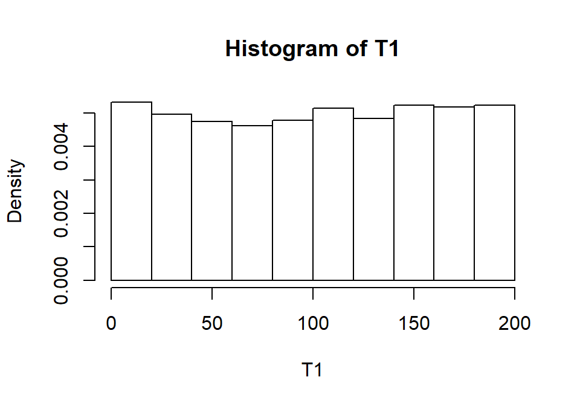

```r
T1=as.matrix(T1)
hist(T1,freq=FALSE)
```

Uniform distrivurion $X \sim \mathrm{U}(a,b)$ where a is the lowest of x and b is the highest value of x

with density function $f(x)= \frac{1}{b-a}$ for $a \le x\le b$

theoretical mean and sd are $\mu = \frac{a+b}{2}$ and $\sigma = \sqrt{\frac{(b-a)^2}{12}}$

- all the value is between

```r
maxT1=max(T1[,1])
minT1=min(T1[,1])
```

- now we compute the sample mean

```r
sm=mean(T1[,1])
ssd=sd(T1[,1])
sm
```

```
## [1] 100.8505
```

```r
ssd
```

```
## [1] 58.42301
```

- we check the theoretical mean and sd, it is very close to the sample true mean and sd

```r
tm=(maxT1+minT1)/2
tsd=sqrt((maxT1-minT1)**2/12)
tm
```

```
## [1] 99.977
```

```r
tsd
```

```
## [1] 57.72175
```

We see from the graph generate random uniform distribution it looks similar as our dataset, that we can say our dataset is uniform distribution

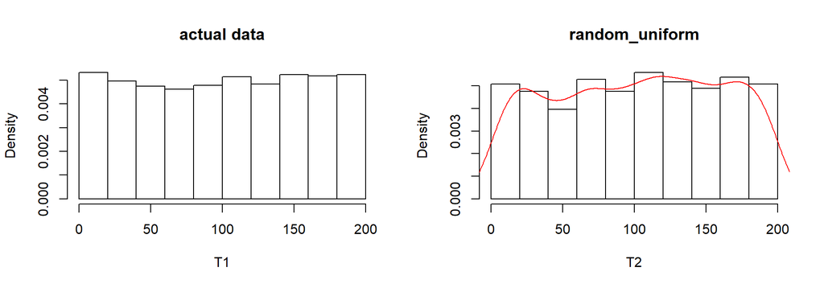

```r
T2=runif(1625, minT1, maxT1)
par(mfrow=c(1,2))
hist(T1,freq=FALSE,main="actual data")
hist(T2, freq = FALSE, main="random_uniform")
lines(density(T2),col='red')
```

```r
#density(T2)
```

We can also check by `ks.test` to perform a one- or two-sample Kolmogorov-Smirnov test.

Here the null hypothesis is that the data follow a uniform distribution. We see that the p-value is high so that we don’t reject the null hypothesis.

```r
ks.test(T1,T2)
```

```
##
##  Two-sample Kolmogorov-Smirnov test
##
## data:  T1 and T2
## D = 0.027077, p-value = 0.5906
## alternative hypothesis: two-sided
```

## (b) Now if we consider the time between two events, how can you modelize this distribution?

draw the histogram of the difference between the data, it seems to be exponential distribution

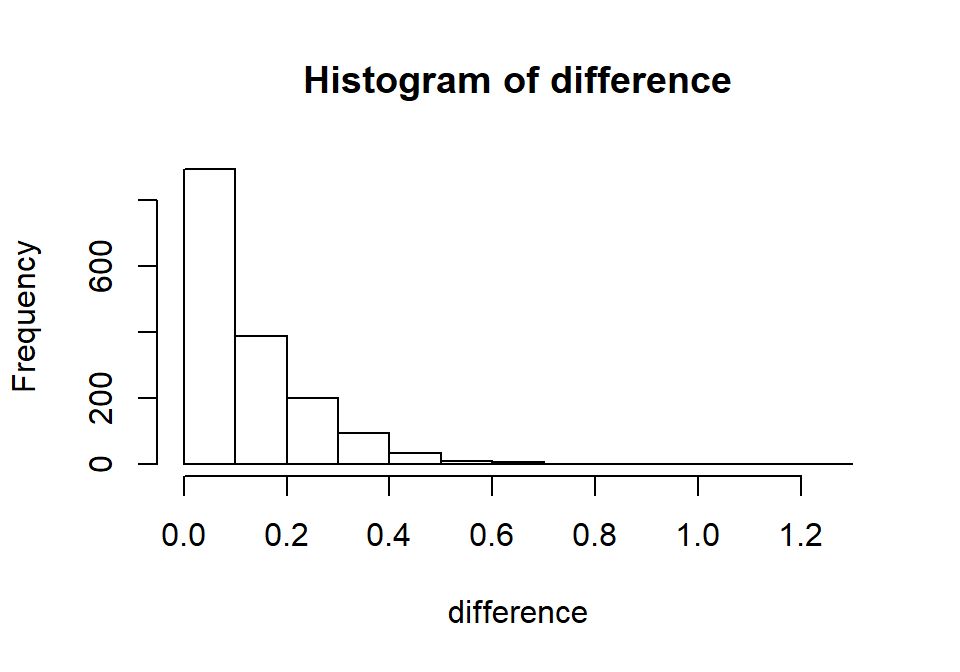

```r
difference=diff(T1[,1])
hist(difference)
```

if $x\sim E(\lambda)$, $\mathbb E[x]=\frac{1}{\lambda}$

```r
#actual
m=mean(difference)
m
```

```
## [1] 0.1231244
```

```r
#theoretical
lambda=1/m
lambda
```

```
## [1] 8.121868
```

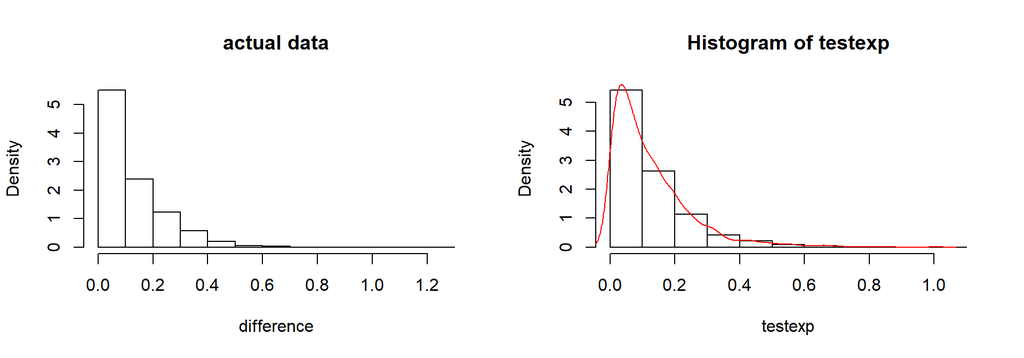

```r
#compare 2 histogram

par(mfrow=c(1,2))
hist(difference,freq=FALSE,main="actual data")
#curve(dexp(lambda))
testexp=rexp(n=length(difference),lambda)
hist(testexp,freq = FALSE)
#curve(dexp,xlim = c(0,1.2),add = TRUE)
lines(density(testexp),col='red')
```

We can also use `ks.test` to check the goodness of fit for exponential distribution. As the p-value is high we also don’t reject the null hypothesis that is the difference is exponential distribution.

```r
ks.test(difference,testexp)
```

```
##
##  Two-sample Kolmogorov-Smirnov test
##
## data:  difference and testexp
## D = 0.030172, p-value = 0.4506
## alternative hypothesis: two-sided
```

## (c) Guess the value of the parameter and compute a confidence interval for it.

we assum that lambda is 8.121868, we are going to compute the confidence interval

- Thanks to Central Limit theorem we have $\sqrt n \frac{\overline{x_{n}}-\mu}{\sigma} \sim \mathcal{N}(0,1)$
- we denote that:
  1. $\mu=\mathbb E[x]$ which is $\frac{1}{\lambda}$ in exponential distribution
  2. $\sigma = \sqrt {V[x]}$ which is $\sqrt{\frac{1}{\lambda^2}}$
- so we can get: $\sqrt n (\lambda \overline{x_n}-1) \sim \mathcal{N}(0,1)$
- we define S and T such that: $\mathrm{P}(\sqrt n (\lambda \overline{x_n}-1) \in [S,T])=1-\alpha$
- we make a choice that S=-T, so T is the fractile of $1-\frac{\alpha}{2}$
- it means that $P(\mathcal{N}(0,1) \le t)=1-\frac{\alpha}{2}$

  $\mathrm{P}(\sqrt n (\lambda \overline{x_n}-1) \in [-T,T])=1-\alpha$

  $\Leftrightarrow P(\frac{1}{\overline{x}}(1-\frac{t}{\sqrt{n}})\le\lambda\le \frac{1}{\overline{x}}(1+\frac{t}{\sqrt{n}}))$ with $\alpha =0.05$

```r
t=qnorm(0.975) #1-0.05/2
lb=1/m*(1-t/sqrt(length(difference)))
ub=1/m*(1+t/sqrt(length(difference)))
cat("confidence interval:[",c(lb,ub),"]")
```

```
## confidence interval:[ 7.726855 8.516881 ]
```

# Exercise 4:

Let $X$ be a random variable whose distribution is an exponential with parameter $\lambda$ > 0

## (a) We define the conditional probability $\mathrm{P}(A \mid B)$ by:

$$\mathrm{P}(A \mid B)= \frac{\mathrm{P}(A \cap B)}{\mathrm{P}(B)}$$

if $P(B)\ne 0$ Prove that the exponential random variable is with no memory which means:

$$\forall s,t >0, \quad \mathrm P(X>t+s \mid X>t)=P(X>s)$$

- for exponential cumulative probability $P(X<x)=1-e^{-\lambda x}$ that is $P(X>x)=e^{-\lambda x}$
- equations:

  $P(X>t+s \mid X>t)= \frac{P(X>t+s \quad\cap\quad X >t)}{P(X>t)}=\frac{P(X>t+s)}{P(x>t)}$

  $\Leftrightarrow \frac{e^{-\lambda (t+s)}}{e^{-\lambda t}}=\frac{e^{-\lambda t}\times e^{-\lambda s}}{e^{-\lambda t}}=e^{-\lambda s}$

  $\Leftrightarrow P(X>s)$

*here since it is exponential distribution and s,t > 0, we can say that $P(X>t+s \cap X >t)=P(X>t+s)$*

- let’s try with the code, set lambda=1, random choose an integer between 1 to 5 for t and s

```r
#random choose t and s
set.seed(10)
t=sample(1:5,1)
s=sample(1:5,1)
t
```

```
## [1] 3
```

```r
s
```

```
## [1] 1
```

```r
(1-pexp(t+s))/(1-pexp(t))
```

```
## [1] 0.3678794
```

```r
1-pexp(s)
```

```
## [1] 0.3678794
```

## (b) Let’s consider $Y=E(x)+1$ where E(x) is the biggest integer smaller or equal to x

let’s try with 1000 random data, here we can see that our data is not anymore continuous. Moreover, y cannot be 0 the smallest is 1, we can assum it to be geometric distribution.

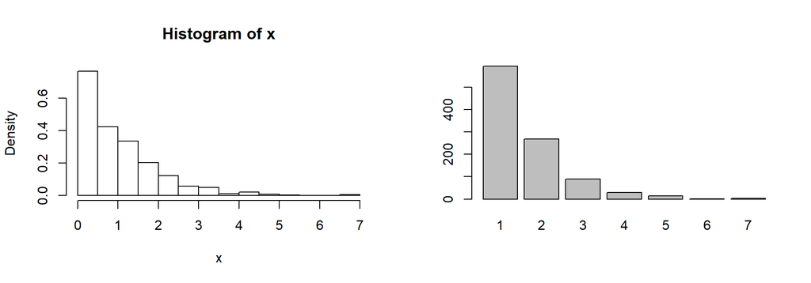

```r
set.seed(10)
par(mfrow=c(1,2))
x=rexp(1000)
hist(x, freq=FALSE)
y=floor(x)+1
barplot(table(y))
```

```r
table(y)
```

```
## y
##   1   2   3   4   5   6   7
## 595 268  90  30  14   1   2
```

with Geometric distribution, $\mu=\frac{1}{p}$ therefor we get p=0.6207325 and we do a random 1000 data from geometric distribution to see if it looks like our y. But `rgeom` start at 0 so we can add the value all to 1

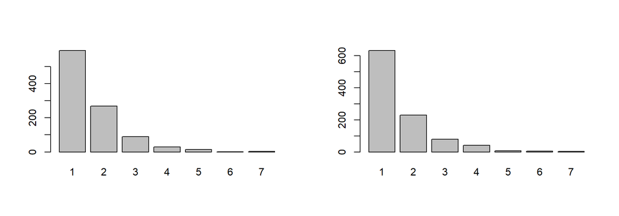

```r
gp=1/mean(y)
par(mfrow=c(1,2))
barplot(table(y))
rg=rgeom(1000,gp)+1
barplot(table(rg))
```

We can then check the distribution from `ks.test`, but since ks.test is meant to use for continouse variable, therefore I use `chisq.test` instead and it suggest me that it is a geometric distribution.

```r
#ks.test(y,rg)
chisq.test(y,rg)
```

```
##
##  Pearson's Chi-squared test
##
## data:  y and rg
## X-squared = 25.789, df = 36, p-value = 0.8962
```